# DA 101 Lec 05

Ali Miller

11 September, 2019

## Wake-up Challenge: Tidy up the Billboard Data using gather()

```r
billboard <- read_csv("billboard.csv")


billboard %>% head
```

| year | artist.inverted | track | time | genre | date.entered | date.peaked | x1st.week | x2nd.week | x3rd.week | x4th.week |
| --- | --- | --- | --- | --- | --- | --- | --- | --- | --- | --- |
| 2000 | Destiny's Child | Independent Women Part I | 03:38:00 | Rock | 9/23/00 | 11/18/00 | 78 | 63 | 49 | 33 |
| 2000 | Santana | Maria, Maria | 04:18:00 | Rock | 2/12/00 | 4/8/00 | 15 | 8 | 6 | 5 |
| 2000 | Savage Garden | I Knew I Loved You | 04:07:00 | Rock | 10/23/99 | 1/29/00 | 71 | 48 | 43 | 31 |
| 2000 | Madonna | Music | 03:45:00 | Rock | 8/12/00 | 9/16/00 | 41 | 23 | 18 | 14 |
| 2000 | Aguilera, Christina | Come On Over Baby (All I Want Is You) | 03:38:00 | Rock | 8/5/00 | 10/14/00 | 57 | 47 | 45 | 29 |
| 2000 | Janet | Doesn't Really Matter | 04:17:00 | Rock | 6/17/00 | 8/26/00 | 59 | 52 | 43 | 30 |

```r
billboard %>% gather(x1st.week, x2nd.week, x3rd.week, x4th.week, key = "week", value="rank")
```

| year | artist.inverted | track | time | genre | date.entered | date.peaked | week | rank |
| --- | --- | --- | --- | --- | --- | --- | --- | --- |
| 2000 | Destiny's Child | Independent Women Part I | 03:38:00 | Rock | 9/23/00 | 11/18/00 | x1st.week | 78 |
| 2000 | Santana | Maria, Maria | 04:18:00 | Rock | 2/12/00 | 4/8/00 | x1st.week | 15 |
| 2000 | Savage Garden | I Knew I Loved You | 04:07:00 | Rock | 10/23/99 | 1/29/00 | x1st.week | 71 |
| 2000 | Madonna | Music | 03:45:00 | Rock | 8/12/00 | 9/16/00 | x1st.week | 41 |
| 2000 | Aguilera, Christina | Come On Over Baby (All I Want Is You) | 03:38:00 | Rock | 8/5/00 | 10/14/00 | x1st.week | 57 |
| 2000 | Janet | Doesn't Really Matter | 04:17:00 | Rock | 6/17/00 | 8/26/00 | x1st.week | 59 |
| 2000 | Destiny's Child | Say My Name | 04:31:00 | Rock | 12/25/99 | 3/18/00 | x1st.week | 83 |
| 2000 | Iglesias, Enrique | Be With You | 03:36:00 | Latin | 4/1/00 | 6/24/00 | x1st.week | 63 |
| 2000 | Sisqo | Incomplete | 03:52:00 | Rock | 6/24/00 | 8/12/00 | x1st.week | 77 |
| 2000 | Lonestar | Amazed | 04:25:00 | Country | 6/5/99 | 3/4/00 | x1st.week | 81 |

[output cut: 1258 more lines]

#### Ex: spreading table2

See text, page chapter 12.

## Data Wrangling

When loading with read_csv, the command will try to *guess* what data types.

```r
death <- read_csv("death penalty data.csv")

death %>% head
```

| Date | Name | Age | Sex | Race | Crime | Victim Count | Victim Sex | Victim Race | County | State | Region | Method | Juvenile | Volunteer | Federal | Foreign National |
| --- | --- | --- | --- | --- | --- | --- | --- | --- | --- | --- | --- | --- | --- | --- | --- | --- |
| 01/17/1977 | Gary Gilmore | 36 | Male | White | Murder | 1 | Male | White | Utah | UT | West | Firing Squad | No | Yes | No | No |
| 05/25/1979 | John Spenkelink | 30 | Male | White | Murder | 1 | Male | White | Leon | FL | South | Electrocution | No | No | No | No |
| 10/22/1979 | Jesse Bishop | 46 | Male | White | Murder | 1 | Male | White | Clark | NV | West | Gas Chamber | No | Yes | No | No |
| 03/09/1981 | Steven Judy | 24 | Male | White | Murder | 4 | 2 Male, 2 Female | White | Marion | IN | Midwest | Electrocution | No | Yes | No | No |
| 08/10/1982 | Frank Coppola | 38 | Male | White | Murder | 1 | Male | White | Newport News City | VA | South | Electrocution | No | Yes | No | No |
| 12/07/1982 | Charlie Brooks | 40 | Male | Black | Murder | 1 | Male | White | Tarrant | TX | South | Lethal Injection | No | No | No | No |

### Understanding class

```r
class(death$Age)
```

```
## [1] "numeric"
```

We see that R understands that Age is numeric.

Note, it didn’t understand the date! We’d have to teach it what the date format is!

Whenever you load into R (read_csv), always check what data types you have! Things can go wrong!

### Setting data types:

It’s often useful for us to manually set data types in R. Here are a few examples where it’s needed.

### as.factor,

This function changes data type to “factor”, which is what we use for categorical variables.

#### Example: (unclean) CIRP data , HSGPA by SEX

```r
cirpData <- read_csv("CIRP2014Data.csv")


cirpData %>% head
```

| SEX | HSGPA | YRSTUDY1 | YRSTUDY2 | YRSTUDY4 | YRSTUDY5 | YRSTUDY8 | RATE01 | RATE03 | RATE07 | RATE08 | RATE10 | RATE11 | RATE13 | RATE14 | RATE15 | RATE16 | RATE20 | HPW01 | HPW02 | HPW04 | HPW06 | HPW07 | HPW08 | HPW09 | HPW11 | HPW12 | HPW13 |
| --- | --- | --- | --- | --- | --- | --- | --- | --- | --- | --- | --- | --- | --- | --- | --- | --- | --- | --- | --- | --- | --- | --- | --- | --- | --- | --- | --- |
| 1 | 7 | 6 | 6 | 6 | 4 | 6 | 4 | 3 | 4 | 5 | 3 | 4 | 5 | 4 | 4 | 3 | 4 | 7 | 6 | 6 | 3 | 4 | 5 | 2 | 2 | 2 | 3 |
| 2 | 8 | 6 | 6 | 3 | 5 | 6 | 5 | 4 | 3 | 3 | 5 | 3 | 2 | 2 | 4 | 3 | 3 | 5 | 5 | 6 | 3 | 2 | 4 | 1 | 3 | 1 | 5 |
| 2 | 8 | 6 | 6 | 4 | 4 | 6 | 4 | 4 | 4 | 4 | 3 | 5 | 3 | 3 | 3 | 3 | 4 | 8 | 4 | 6 | 1 | 1 | 3 | 2 | 1 | 1 | 4 |
| 1 | 7 | 6 | 7 | 4 | 4 | 6 | 4 | 5 | 4 | 4 | 4 | 4 | 4 | 4 | 4 | 3 | 3 | 2 | 5 | 4 | 2 | 1 | 3 | 5 | 2 | 1 | 3 |
| 2 | 6 | 6 | 6 | 6 | 3 | 1 | 4 | 3 | 4 | 4 | 2 | 4 | 2 | 1 | 4 | 2 | 4 | 7 | 8 | 8 | 1 | 4 | 1 | 5 | 4 | 1 | 7 |
| 2 | 6 | 6 | 6 | NA | 5 | 4 | 4 | 5 | 5 | 4 | 3 | 5 | 3 | 3 | 3 | 3 | 2 | 5 | 7 | 6 | 1 | 1 | 1 | 4 | 1 | 1 | 3 |

Example: graph HSGPA by SEX

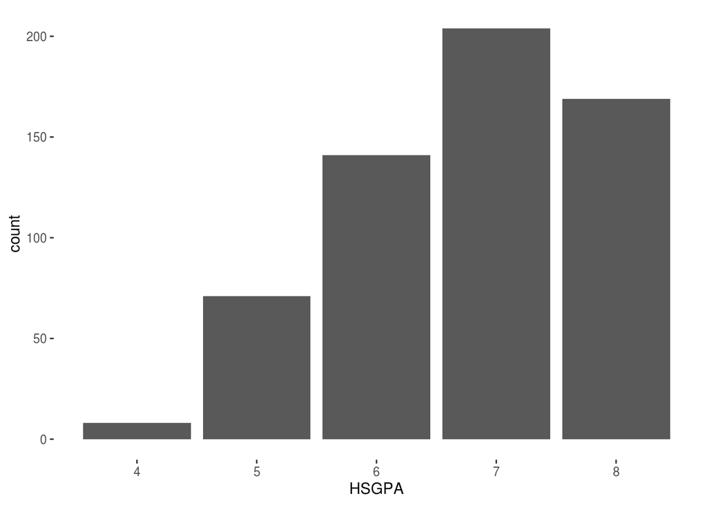

```r
ggplot(cirpData, aes(HSGPA, fill=SEX)) + geom_bar()
```

Note, the fill didn’t work? Why not? R thinks that gender is numerical! 1 and 2!

Fix:

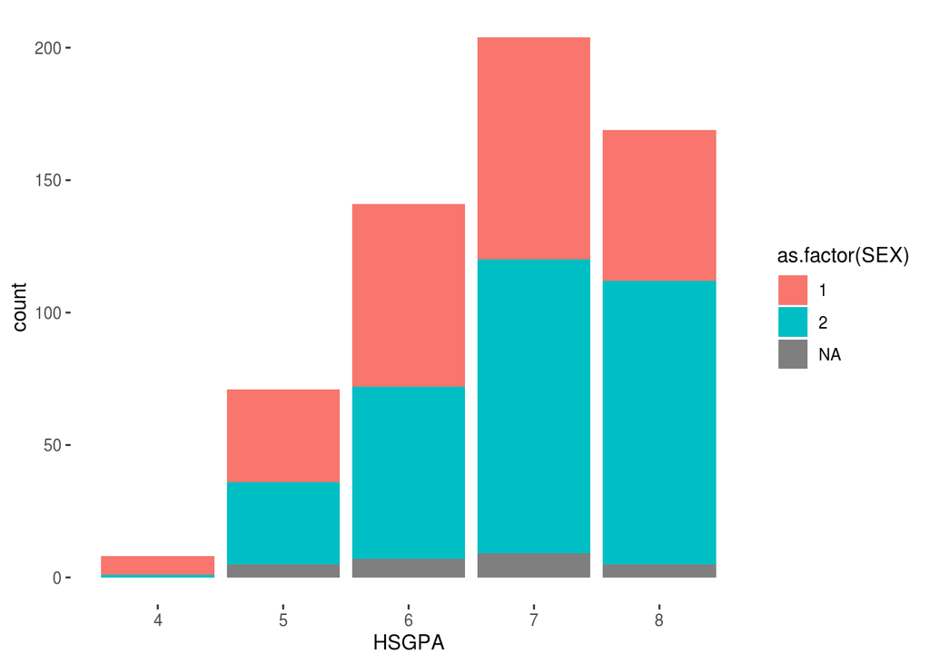

```r
# as.factor turns it into a factor!

ggplot(cirpData, aes(HSGPA, fill= as.factor(SEX) )) + geom_bar()
```

```r
cirpData %>% head
```

| SEX | HSGPA | YRSTUDY1 | YRSTUDY2 | YRSTUDY4 | YRSTUDY5 | YRSTUDY8 | RATE01 | RATE03 | RATE07 | RATE08 | RATE10 | RATE11 | RATE13 | RATE14 | RATE15 | RATE16 | RATE20 | HPW01 | HPW02 | HPW04 | HPW06 | HPW07 | HPW08 | HPW09 | HPW11 | HPW12 | HPW13 |
| --- | --- | --- | --- | --- | --- | --- | --- | --- | --- | --- | --- | --- | --- | --- | --- | --- | --- | --- | --- | --- | --- | --- | --- | --- | --- | --- | --- |
| 1 | 7 | 6 | 6 | 6 | 4 | 6 | 4 | 3 | 4 | 5 | 3 | 4 | 5 | 4 | 4 | 3 | 4 | 7 | 6 | 6 | 3 | 4 | 5 | 2 | 2 | 2 | 3 |
| 2 | 8 | 6 | 6 | 3 | 5 | 6 | 5 | 4 | 3 | 3 | 5 | 3 | 2 | 2 | 4 | 3 | 3 | 5 | 5 | 6 | 3 | 2 | 4 | 1 | 3 | 1 | 5 |
| 2 | 8 | 6 | 6 | 4 | 4 | 6 | 4 | 4 | 4 | 4 | 3 | 5 | 3 | 3 | 3 | 3 | 4 | 8 | 4 | 6 | 1 | 1 | 3 | 2 | 1 | 1 | 4 |
| 1 | 7 | 6 | 7 | 4 | 4 | 6 | 4 | 5 | 4 | 4 | 4 | 4 | 4 | 4 | 4 | 3 | 3 | 2 | 5 | 4 | 2 | 1 | 3 | 5 | 2 | 1 | 3 |
| 2 | 6 | 6 | 6 | 6 | 3 | 1 | 4 | 3 | 4 | 4 | 2 | 4 | 2 | 1 | 4 | 2 | 4 | 7 | 8 | 8 | 1 | 4 | 1 | 5 | 4 | 1 | 7 |
| 2 | 6 | 6 | 6 | NA | 5 | 4 | 4 | 5 | 5 | 4 | 3 | 5 | 3 | 3 | 3 | 3 | 2 | 5 | 7 | 6 | 1 | 1 | 1 | 4 | 1 | 1 | 3 |

```r
# permanently change SEX type:

as.factor(cirpData$SEX) -> cirpData$SEX

## equal to this:

cirpData$SEX <- as.factor(cirpData$SEX)


class(cirpData$SEX)
```

```
## [1] "factor"
```

Question: we’ve got 1s and 2s for gender, but this doesn’t make much sense. How to fix?

Answer: `recode()`. See below!

### as.numeric, as.double, as.integer

We can change lots of data types, see above! These are the least commonly used, since R is good at identifying numbers.

### as.Date

Dates are important! But, R almost never guesses the right format.

#### Example: Lobbyist Data

Read the data:

```r
lobbyData <- read_csv("lobbyist-data-gifts.csv")


lobbyData %>% head
```

| GIFT_ID | PERIOD_START | PERIOD_END | GIFT | RECIPIENT_FIRST_NAME | RECIPIENT_LAST_NAME | RECIPIENT_TITLE | VALUE | DEPARTMENT | LOBBYIST_ID | LOBBYIST_FIRSTNAME | LOBBYIST_LASTNAME | CREATED_DATE |
| --- | --- | --- | --- | --- | --- | --- | --- | --- | --- | --- | --- | --- |
| 1101 | 2012-10-01 | 2012-12-31 | candy | Carl | Erickson | Adm. Asst | 12.00 | CITY COUNCIL / ALDERMEN | 6051 | Constance | Zaio | 2013-01-29 |
| 288 | 2012-01-01 | 2012-06-30 | lunch | Elizabeth | Horton-Newkirk | employee | 12.00 | FIRE DEPARTMENT | 6077 | Amy | Garman | 2012-09-11 |
| 88 | 2012-01-01 | 2012-06-30 | Breakfast | Mary | O'Connor | Alderman | 24.00 | CITY COUNCIL / ALDERMEN | 6082 | Daniel | Lynch | 2012-08-14 |
| 583 | 2012-07-01 | 2012-09-30 | meal / snack | Deborah | Graham | alderman | 13.00 | CITY COUNCIL / ALDERMEN | 6123 | Amy | Brennan | 2012-10-30 |
| 601 | 2012-07-01 | 2012-09-30 | None | None | None | None | 0.00 | WORLD BUSINESS CHICAGO | 5703 | Michael | Laube | 2012-10-31 |
| 933 | 2012-10-01 | 2012-12-31 | Gift Basket | Tamra | Collins | Ms. | 46.45 | HOUSING AND ECONOMIC DEVELOPMENT | 6982 | Virginia | Pace | 2013-01-14 |

```r
#question:  did R get teh date right?

class(lobbyData$PERIOD_START)
```

```
## [1] "POSIXct" "POSIXt"
```

```r
#hmm, maybe doesn't know.  let's use as.Date:

lobbyData$PERIOD_START %>% as.Date(format = "%Y-%m-%d" ) %>% head
```

```
## [1] "2012-10-01" "2012-01-01" "2012-01-01" "2012-07-01" "2012-07-01"
## [6] "2012-10-01"
```

```r
#it worked!  But don't forget to save:

lobbyData$PERIOD_START %>%
  as.Date(format = "%Y-%m-%d" ) ->
  lobbyData$PERIOD_START

#below works equally well:

lobbyData$PERIOD_START <-
  lobbyData$PERIOD_START %>%
  as.Date(format = "%Y-%m-%d" )


lobbyData %>% head
```

| GIFT_ID | PERIOD_START | PERIOD_END | GIFT | RECIPIENT_FIRST_NAME | RECIPIENT_LAST_NAME | RECIPIENT_TITLE | VALUE | DEPARTMENT | LOBBYIST_ID | LOBBYIST_FIRSTNAME | LOBBYIST_LASTNAME | CREATED_DATE |
| --- | --- | --- | --- | --- | --- | --- | --- | --- | --- | --- | --- | --- |
| 1101 | 2012-10-01 | 2012-12-31 | candy | Carl | Erickson | Adm. Asst | 12.00 | CITY COUNCIL / ALDERMEN | 6051 | Constance | Zaio | 2013-01-29 |
| 288 | 2012-01-01 | 2012-06-30 | lunch | Elizabeth | Horton-Newkirk | employee | 12.00 | FIRE DEPARTMENT | 6077 | Amy | Garman | 2012-09-11 |
| 88 | 2012-01-01 | 2012-06-30 | Breakfast | Mary | O'Connor | Alderman | 24.00 | CITY COUNCIL / ALDERMEN | 6082 | Daniel | Lynch | 2012-08-14 |
| 583 | 2012-07-01 | 2012-09-30 | meal / snack | Deborah | Graham | alderman | 13.00 | CITY COUNCIL / ALDERMEN | 6123 | Amy | Brennan | 2012-10-30 |
| 601 | 2012-07-01 | 2012-09-30 | None | None | None | None | 0.00 | WORLD BUSINESS CHICAGO | 5703 | Michael | Laube | 2012-10-31 |
| 933 | 2012-10-01 | 2012-12-31 | Gift Basket | Tamra | Collins | Ms. | 46.45 | HOUSING AND ECONOMIC DEVELOPMENT | 6982 | Virginia | Pace | 2013-01-14 |

### Renaming factor levels with recode

The `recode()` function in dplyr let’s us adjust our factor levels. The “levels” are the possible options for the category; for example in the CIRP data, the levels for SEX are “male” and “female”.

#### Example: (unclean) CIRP data

```r
cirpData %>% head
```

| SEX | HSGPA | YRSTUDY1 | YRSTUDY2 | YRSTUDY4 | YRSTUDY5 | YRSTUDY8 | RATE01 | RATE03 | RATE07 | RATE08 | RATE10 | RATE11 | RATE13 | RATE14 | RATE15 | RATE16 | RATE20 | HPW01 | HPW02 | HPW04 | HPW06 | HPW07 | HPW08 | HPW09 | HPW11 | HPW12 | HPW13 |
| --- | --- | --- | --- | --- | --- | --- | --- | --- | --- | --- | --- | --- | --- | --- | --- | --- | --- | --- | --- | --- | --- | --- | --- | --- | --- | --- | --- |
| 1 | 7 | 6 | 6 | 6 | 4 | 6 | 4 | 3 | 4 | 5 | 3 | 4 | 5 | 4 | 4 | 3 | 4 | 7 | 6 | 6 | 3 | 4 | 5 | 2 | 2 | 2 | 3 |
| 2 | 8 | 6 | 6 | 3 | 5 | 6 | 5 | 4 | 3 | 3 | 5 | 3 | 2 | 2 | 4 | 3 | 3 | 5 | 5 | 6 | 3 | 2 | 4 | 1 | 3 | 1 | 5 |
| 2 | 8 | 6 | 6 | 4 | 4 | 6 | 4 | 4 | 4 | 4 | 3 | 5 | 3 | 3 | 3 | 3 | 4 | 8 | 4 | 6 | 1 | 1 | 3 | 2 | 1 | 1 | 4 |
| 1 | 7 | 6 | 7 | 4 | 4 | 6 | 4 | 5 | 4 | 4 | 4 | 4 | 4 | 4 | 4 | 3 | 3 | 2 | 5 | 4 | 2 | 1 | 3 | 5 | 2 | 1 | 3 |
| 2 | 6 | 6 | 6 | 6 | 3 | 1 | 4 | 3 | 4 | 4 | 2 | 4 | 2 | 1 | 4 | 2 | 4 | 7 | 8 | 8 | 1 | 4 | 1 | 5 | 4 | 1 | 7 |
| 2 | 6 | 6 | 6 | NA | 5 | 4 | 4 | 5 | 5 | 4 | 3 | 5 | 3 | 3 | 3 | 3 | 2 | 5 | 7 | 6 | 1 | 1 | 1 | 4 | 1 | 1 | 3 |

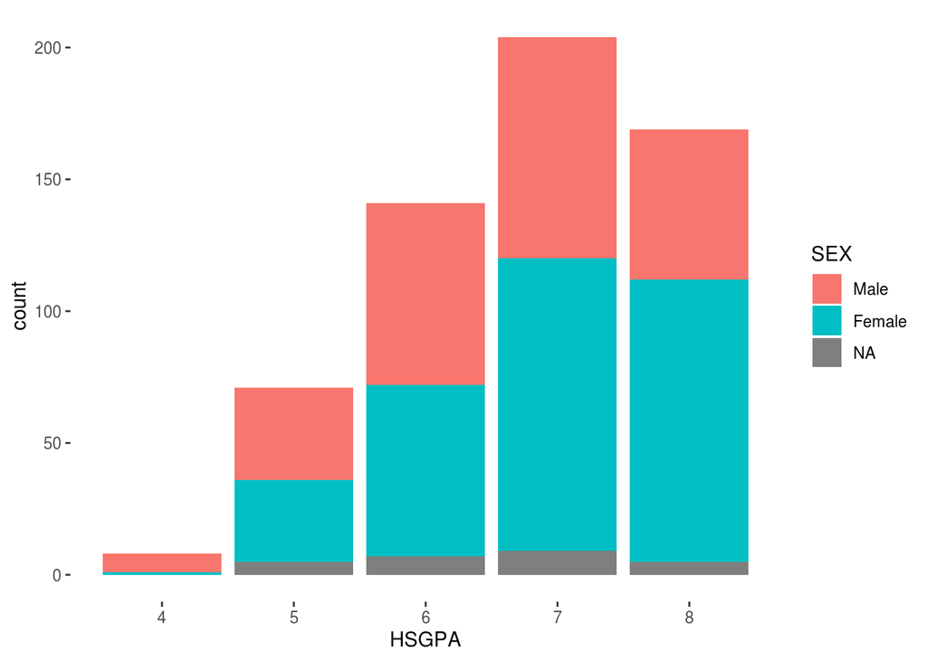

```r
#pipe it into recode

cirpData$SEX %>% recode(`1`= "Male", `2`="Female") ->
  cirpData$SEX

#Now, labels in graph are fixed:

cirpData %>% ggplot(aes(HSGPA, fill=SEX))+geom_bar()
```

## Joining Tables

### Example: Lahman baseball scores database